# COVID-19 US Weekly Forecast Summary

[The COVID-19 Forecast Hub Team](https://covid19forecasthub.org/doc/) https://covid19forecasthub.org/

report generated 2021-03-09

# Background

This report provides a brief summary of the weekly ensemble forecast from the [COVID-19 Forecast Hub](https://covid19forecasthub.org/) based on forecasts submitted on March 01, 2021. In collaboration with the US CDC, our team aggregates COVID-19 forecasts from dozens of teams around the globe. Typically on Wednesday of each week, a summary of the week’s forecasts from the COVID-19 Forecast Hub appear on the [official CDC COVID-19 forecasting page](https://www.cdc.gov/coronavirus/2019-ncov/covid-data/forecasting-us.html).

Every week, teams submit their forecasts to the COVID-19 Forecast Hub. This past week, 60 models were submitted.

Each Monday evening or Tuesday morning, we combine the most recent forecasts from each team into a single “ensemble” forecast of reported COVID-19 cases at the county, state, and national level and deaths at the state and national level. At the moment, we only generate ensemble forecasts for four weeks into the future, as [the available evidence](https://www.medrxiv.org/content/10.1101/2021.02.03.21250974v1) suggests that models are less accurate at longer forecast horizons.

An archive of weekly reports from the COVID-19 Forecast Hub can be found at [this page](https://covid19forecasthub.org/doc/reports/).

# COVID-19 Forecasts

## National level

This week, our ensemble combined forecasts from 46 different models.

At the national level, the ensemble model predicts that weekly totals of observed deaths in each of the next four weeks will be between 7,800 and 11,500 deaths with around 550,400 deaths by March 27 (95% prediction interval: 540,450 - 564,415).

For the week ending March 27, the ensemble forecasts that reported COVID-19 deaths in the US will be between 4,400 and 12,900 (95% prediction interval: 4,369 - 12,856) and COVID-19 cases in the US will be between 165,900 and 563,200 (95% prediction interval: 165,938 - 563,245).

For March 29, 2021 COVID-19 daily hospitalizations in the US will be between 1,900 and 10,000 (95% prediction interval: 1,932 - 9,950).

You can explore the full set of models, including their forecasts for past weeks online at our [interactive forecast visualization](https://viz.covid19forecasthub.org/).

### Deaths

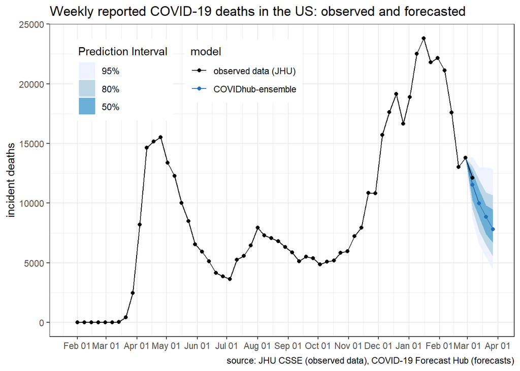

### Cases

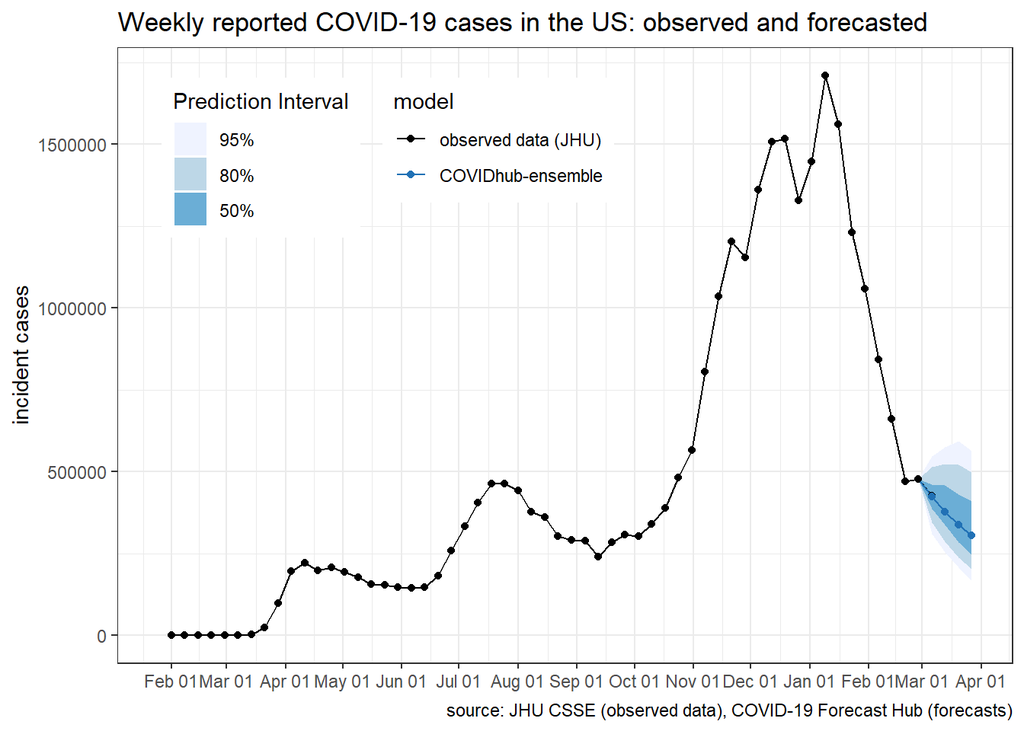

### Daily Hospitalizations

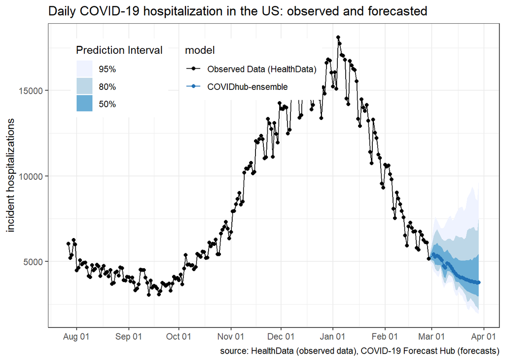

## State level

The ensemble model estimates that 8 states and territories of the US have a greater than 50% chance of having more deaths in the next two weeks compared to the past two weeks.The model forecasts that 3 states and territories have a greater than 75% chance of an increase over the next two weeks (American Samoa, Northern Mariana Islands, Virgin Islands).

The sortable and searchable table below shows the total number of reported COVID-19 deaths at the US level and by state over the last two weeks (ending Saturday, February 27, 2021) and the forecasted counts for the subsequent two weeks (ending March 13, 2021).

| state | Population | Total COVID-19 deaths | COVID-19 deaths, last 2 weeks | COVID-19 deaths, next 2 weeks | Difference |
| --- | --- | --- | --- | --- | --- |
| Rhode Island | 1059361 | 2502 | 43 | 64 | 21 |
| Oregon | 4217737 | 2208 | 71 | 78 | 7 |
| Alaska | 731545 | 290 | 8 | 9 | 1 |
| Montana | 1068778 | 1356 | 30 | 30 | 0 |
| North Dakota | 762062 | 1475 | 14 | 14 | 0 |
| American Samoa | 55641 | 0 | 0 | 0 | 0 |
| Northern Mariana Islands | 55144 | 2 | 0 | 0 | 0 |
| Virgin Islands | 107268 | 25 | 0 | 0 | 0 |
| Hawaii | 1415872 | 438 | 14 | 13 | -1 |
| Vermont | 623989 | 204 | 15 | 14 | -1 |

[output cut: 47 more lines]

Looking at the rates allows for easier comparison across states, where you can see which states have had or are predicted to have proportionally higher rates in comparison to other states.

The sortable and searchable death table below shows the total number of reported COVID-19 deaths at the US level and by state as of Saturday, February 27, 2021 (“Total COVID-19 Deaths”) as well as the rate of reported COVID-19 deaths in the population (standardized per 100,000 population) over the last two weeks and over the next two weeks.

The sortable and searchable case table below shows the weekly case count and rate of reported COVID-19 case in the population (standardized per 100,000 population) over the last week (February 21, 2021 to February 27, 2021) and two weeks ahead (March 07, 2021 to March 13, 2021).

The sortable and searchable hospitalization table below shows the 7 day average hospitalization count and rate of reported COVID-19 hospitalization in the population (standardized per 100,000 population) over the last week (February 21, 2021 to February 27, 2021) and two weeks ahead (March 07, 2021 to March 13, 2021).

When interpreting probability of an increase, it’s important to note that the increase or decrease is relative to the location-specific recent observed incidence, which varies across locations.

### Death rates

| state | Population | Total COVID-19 deaths | Daily deaths per 100k, last 2 weeks | Daily deaths per 100k, next 2 weeks | Death rate difference |
| --- | --- | --- | --- | --- | --- |
| Rhode Island | 1059361 | 2502 | 0.29 | 0.432 | 0.142 |
| Oregon | 4217737 | 2208 | 0.12 | 0.132 | 0.012 |
| Alaska | 731545 | 290 | 0.078 | 0.088 | 0.01 |
| Montana | 1068778 | 1356 | 0.2 | 0.2 | 0 |
| North Dakota | 762062 | 1475 | 0.131 | 0.131 | 0 |
| American Samoa | 55641 | 0 | 0 | 0 | 0 |
| Northern Mariana Islands | 55144 | 2 | 0 | 0 | 0 |
| Virgin Islands | 107268 | 25 | 0 | 0 | 0 |
| Minnesota | 5639632 | 6543 | 0.134 | 0.132 | -0.002 |
| Hawaii | 1415872 | 438 | 0.071 | 0.066 | -0.005 |

[output cut: 47 more lines]

### Case rates

[interactive table not shown]

### Hospitalization rates

[interactive table not shown]

This report was reproducibly and dynamically generated using RMarkdown. The code for the report can be found [here](https://github.com/reichlab/covid19-forecast-hub/tree/master/code/reports).